# project

jeong minji

2021 4 28

## 연습문제01

### mpg 데이터의 cty(도시 연비)와 hwy(고속도로 연비) 간에 어떤 관계가 있는지 알아보려고 합니다. x축은 cty, y축은 hwy로 된 산점도를 만들어 보세요.

```r
head(mpg)
```

```
## # A tibble: 6 x 11
##   manufacturer model displ  year   cyl trans      drv     cty   hwy fl    class
##   <chr>        <chr> <dbl> <int> <int> <chr>      <chr> <int> <int> <chr> <chr>
## 1 audi         a4      1.8  1999     4 auto(l5)   f        18    29 p     compa~
## 2 audi         a4      1.8  1999     4 manual(m5) f        21    29 p     compa~
## 3 audi         a4      2    2008     4 manual(m6) f        20    31 p     compa~
## 4 audi         a4      2    2008     4 auto(av)   f        21    30 p     compa~
## 5 audi         a4      2.8  1999     6 auto(l5)   f        16    26 p     compa~
## 6 audi         a4      2.8  1999     6 manual(m5) f        18    26 p     compa~
```

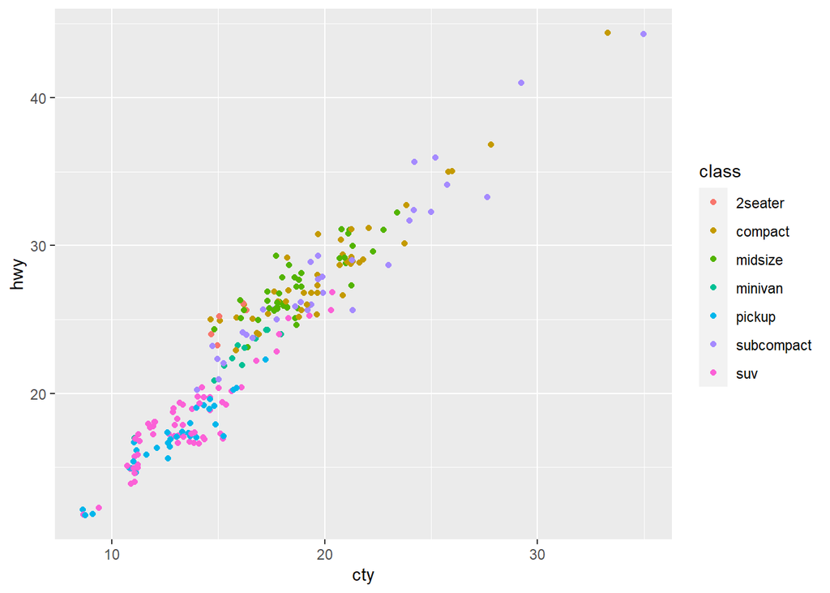

```r
ggplot(mpg, aes(cty, hwy, col=class)) +
    geom_point(position='jitter')
```

## 연습문제02 ### 미국 지역별 인구통계 정보를 담은 ggplot2 패키지의 midwest 데이터를 이용해서 전체 인구와 아시아인 인구 간에 어떤 관계가 있는지 알아보려고 합니다. x축은 poptotal(전체 인구), y축은 popasian(아시아인 인구)으로 된 산점도를 만들어 보세요. 전체 인구는 50만 명 이하, 아시아인 인구는 1만 명 이하인 지역만 산점도에 표시되게 설정하세요.

```r
head(midwest)
```

```
## # A tibble: 6 x 28
##     PID county   state  area poptotal popdensity popwhite popblack popamerindian
##   <int> <chr>    <chr> <dbl>    <int>      <dbl>    <int>    <int>         <int>
## 1   561 ADAMS    IL    0.052    66090      1271.    63917     1702            98
## 2   562 ALEXAND~ IL    0.014    10626       759      7054     3496            19
## 3   563 BOND     IL    0.022    14991       681.    14477      429            35
## 4   564 BOONE    IL    0.017    30806      1812.    29344      127            46
## 5   565 BROWN    IL    0.018     5836       324.     5264      547            14
## 6   566 BUREAU   IL    0.05     35688       714.    35157       50            65
## # ... with 19 more variables: popasian <int>, popother <int>, percwhite <dbl>,
## #   percblack <dbl>, percamerindan <dbl>, percasian <dbl>, percother <dbl>,
## #   popadults <int>, perchsd <dbl>, percollege <dbl>, percprof <dbl>,
## #   poppovertyknown <int>, percpovertyknown <dbl>, percbelowpoverty <dbl>,
## #   percchildbelowpovert <dbl>, percadultpoverty <dbl>,
## #   percelderlypoverty <dbl>, inmetro <int>, category <chr>
```

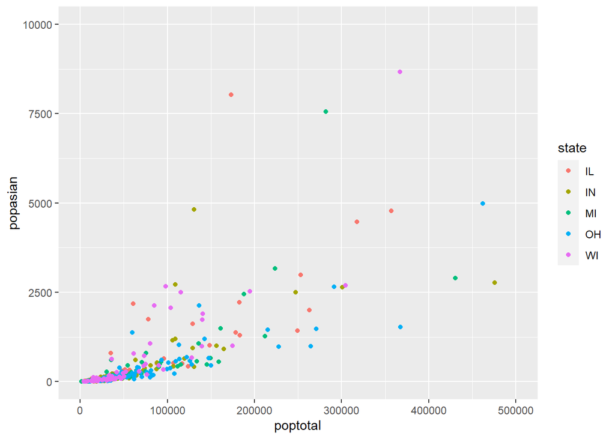

```r
options(scipen = 10)   # 지수 표기를 일반 표기로 변환
mw <- midwest %>%
    filter(poptotal <= 500000 & popasian <= 10000)
ggplot(mw, aes(x=poptotal, y=popasian, col=state)) +
    geom_point() +
    xlim(0,500000) + ylim(0,10000)
```

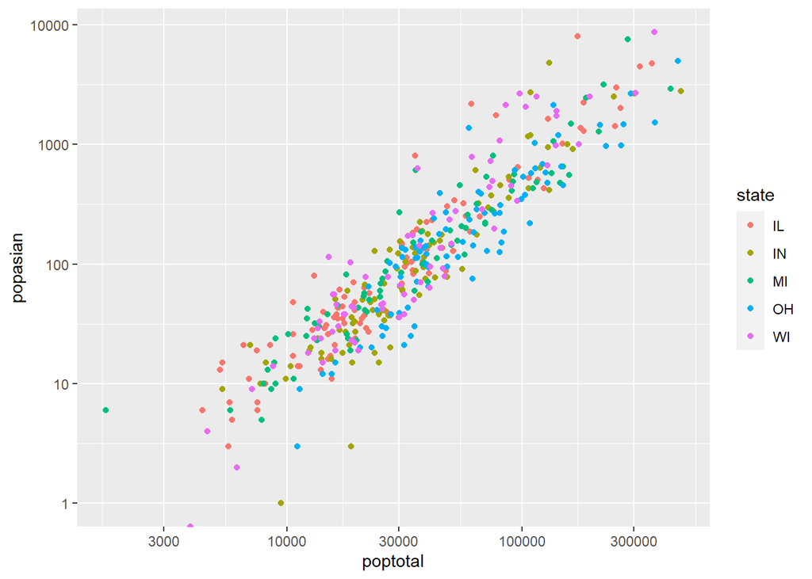

```r
# 연결해서 한번에 실행되도록, 스케일 변화
midwest %>%
    filter(poptotal <= 500000 & popasian <= 10000) %>%
    ggplot(aes(x=poptotal, y=popasian, col=state)) +
    geom_point() +
    scale_x_log10() + scale_y_log10()
```

## 연습문제03

### 어떤 회사에서 생산한 “suv” 차종의 도시 연비가 높은지 알아보려고 합니다. “suv” 차종을 대상으로 평균 cty(도시 연비)가 가장 높은 회사 다섯 곳을 막대 그래프로 표현해 보세요. 막대는 연비가 높은 순으로 정렬하세요.

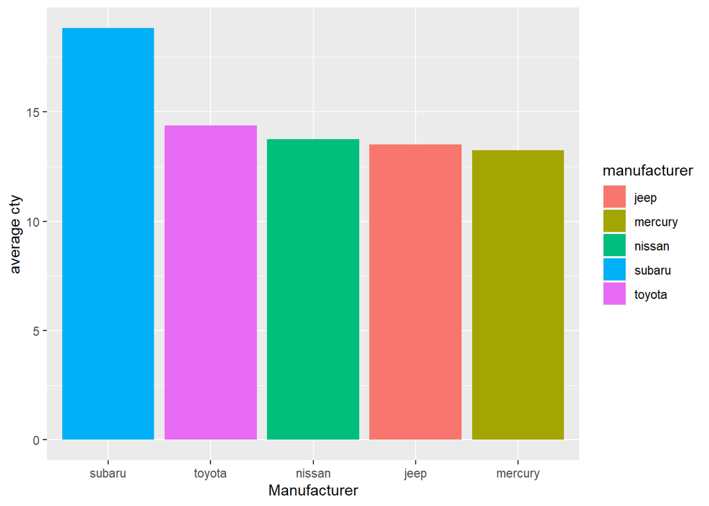

```r
mpg %>%
    filter(class=='suv') %>%
    group_by(manufacturer) %>%
    summarise(mean_cty = mean(cty)) %>%
    arrange(desc(mean_cty)) %>%
    head(5) %>%
    ggplot(aes(x=reorder(manufacturer, -mean_cty),y=mean_cty,fill=manufacturer)) +
    geom_col() +
    labs(x='Manufacturer',y='average cty')
```

## 연습문제04 ### 자동차 중에서 어떤 class(자동차 종류)가 가장 많은지 알아보려고 합니다. 자동차 종류별 빈도를 표현한 막대 그래프를 만들어 보세요.

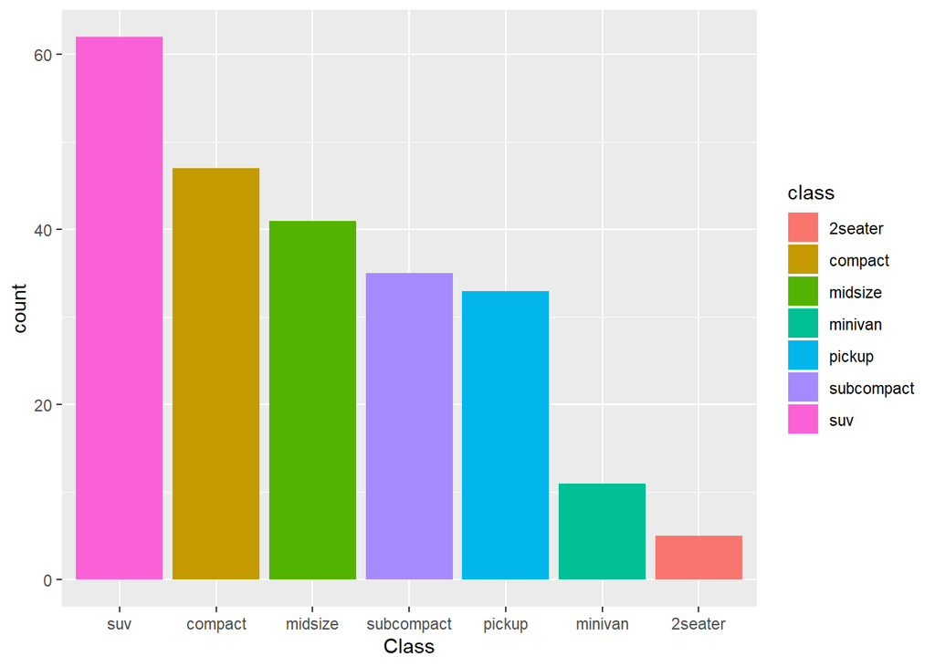

```r
mpg %>%
    group_by(class) %>%
    summarise(count=n()) %>%
    ggplot(aes(x=reorder(class,-count),y=count,fill=class)) +
    geom_col() +
    labs(x='Class')
```

## 연습문제05 ### economics 데이터를 이용해서 psavert(개인 저축률)가 시간에 따라서 어떻게 변해왔는지 알아보려고 합니다. 시간에 따른 개인 저축률의 변화를 나타낸 시계열 그래프를 만들어 보세요.

```r
head(economics)
```

```
## # A tibble: 6 x 6
##   date         pce    pop psavert uempmed unemploy
##   <date>     <dbl>  <dbl>   <dbl>   <dbl>    <dbl>
## 1 1967-07-01  507. 198712    12.6     4.5     2944
## 2 1967-08-01  510. 198911    12.6     4.7     2945
## 3 1967-09-01  516. 199113    11.9     4.6     2958
## 4 1967-10-01  512. 199311    12.9     4.9     3143
## 5 1967-11-01  517. 199498    12.8     4.7     3066
## 6 1967-12-01  525. 199657    11.8     4.8     3018
```